# Schelling’s Segregation Model

Jing Fang and Shihui Ma

# Overview

# Overview

- In 1969, Thomas C. Schelling developed a simple but striking model of racial segregation
- His model studies the dynamics of racially mixed neighborhoods
- Like much of Schelling’s work, the model shows how local interactions can lead to surprising aggregate structure
- In particular, it shows that relatively mild preference for neighbors of similar race can lead in aggregate to the collapse of mixed neighborhoods, and high levels of segregation

# Overview

- In recognition of this and other research, Schelling was awarded the 2005 Nobel Prize in Economic Sciences (joint with Robert Aumann)
- In this lecture we will build and run a version of Schelling’s model

# The Model

# Set Up

- Suppose we have two types of people: orange people and green people
- For the purpose of this lecture, we will assume there are 250 of each type
- These agents all live on a single unit square
- The location of an agent is just a point $(x,y)$, where $0<x,y<1$

# Preferences

- We will say that an agent is *happy* if half or more of her 10 nearest neighbors are of the same type
- Here ‘nearest’ is in terms of Euclidean distance
- An agent who is not happy is called *unhappy*
- An important point here is that agents are not averse to living in mixed areas
- They are perfectly happy if half their neighbors are of the other color

# Behavior

- Initially, agents are mixed together (integrated)
- In particular, the initial location of each agent is an independent draw from a bivariate uniform distribution on $S=(0,1)^2$
- Now, cycling through the set of all agents, each agent is now given the chance to stay or move
- We assume that each agent will stay put if they are happy and move if unhappy

# Behavior

- The algorithm for moving is as follows
  - Draw a random location in $S$
  - If happy at new location, move there
  - Else, go to step 1
- In this way, we cycle continuously through the agents, moving as required
- We continue to cycle until no one wishes to move

# Results

# Results

- Let’s have a look at the results we got when we coded and ran this model
- As discussed above, agents are initially mixed randomly together

# Results

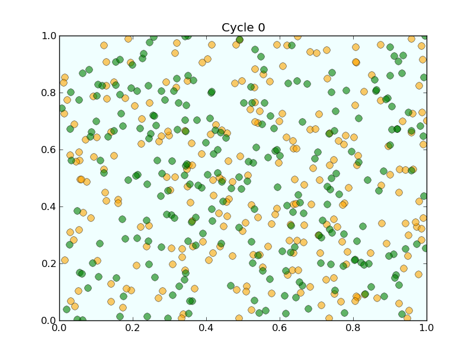

# Results

- But after several cycles they become segregated into distinct regions

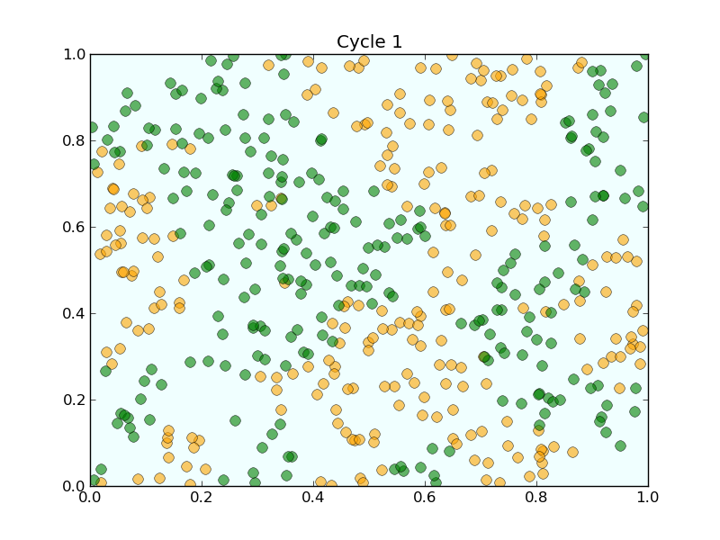

# Results

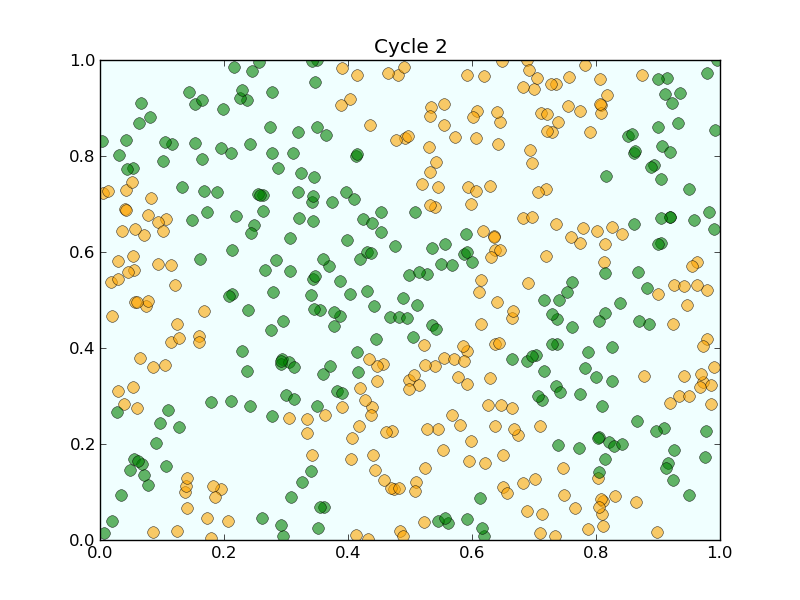

# Results

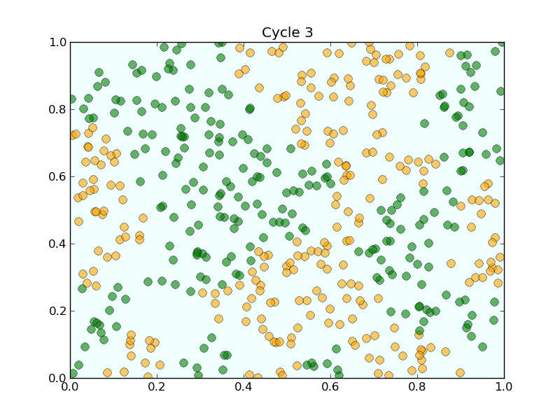

# Results

- In this instance, the program terminated after 4 cycles through the set of agents, indicating that all agents had reached a state of happiness
- What is striking about the pictures is how rapidly racial integration breaks down
- This is despite the fact that people in the model don’t actually mind living mixed with the other type
- Even with these preferences, the outcome is a high degree of segregation

# Exercises

# Exercises

- Rather than show you the program that generated these figures, we’ll now ask you to write your own version
- You can see our program at the end, when you look at the solution

# Exercise 1

- Consider the following structure for your program
- Agents are modeled as objects
- Here’s an indication of how they might look

```
* Data:
    * type (green or orange)
    * location
* Methods:
    * Determine whether happy or not given locations of other agents
    * If not happy, move
        * find a new location where happy
```

# Exercise 1

- And here’s some pseudocode for the main loop

```
while agents are still moving:
    for agent in agents:
        give agent the opportunity to move
```

- Use 250 agents of each type